# Project: Investigate a Dataset (Movies)

# Use this cell to set up import statements for all of the packages that you

# plan to use.

# Remember to include a 'magic word' so that your visualizations are plotted

# inline with the notebook. See this page for more:

# http://ipython.readthedocs.io/en/stable/interactive/magics.html

```python
import pandas as pd
import numpy as np
import matplotlib.pyplot as plt
import seaborn as sb
from collections import Counter


% matplotlib inline
```

## Data Wrangling

### General Properties

```python
# storing the file to tmdb_movies
tmdb_data = pd.read_csv('tmdb-movies.csv')
#show the first three rows:
print(f"Number of movies in tmdb movies dataset: {tmdb_data.shape}")
tmdb_data.head(3)
```

```
Number of movies in tmdb movies dataset: (10866, 21)
```

|  | id | imdb_id | popularity | budget | revenue | original_title | cast | homepage | director | tagline | ... | overview | runtime | genres | production_companies | release_date | vote_count | vote_average | release_year | budget_adj | revenue_adj |
| --- | --- | --- | --- | --- | --- | --- | --- | --- | --- | --- | --- | --- | --- | --- | --- | --- | --- | --- | --- | --- | --- |
| 0 | 135397 | tt0369610 | 32.985763 | 150000000 | 1513528810 | Jurassic World | Chris Pratt\|Bryce Dallas Howard\|Irrfan Khan\|Vi... | http://www.jurassicworld.com/ | Colin Trevorrow | The park is open. | ... | Twenty-two years after the events of Jurassic ... | 124 | Action\|Adventure\|Science Fiction\|Thriller | Universal Studios\|Amblin Entertainment\|Legenda... | 6/9/2015 | 5562 | 6.5 | 2015 | 137999939.3 | 1.392446e+09 |
| 1 | 76341 | tt1392190 | 28.419936 | 150000000 | 378436354 | Mad Max: Fury Road | Tom Hardy\|Charlize Theron\|Hugh Keays-Byrne\|Nic... | http://www.madmaxmovie.com/ | George Miller | What a Lovely Day. | ... | An apocalyptic story set in the furthest reach... | 120 | Action\|Adventure\|Science Fiction\|Thriller | Village Roadshow Pictures\|Kennedy Miller Produ... | 5/13/2015 | 6185 | 7.1 | 2015 | 137999939.3 | 3.481613e+08 |
| 2 | 262500 | tt2908446 | 13.112507 | 110000000 | 295238201 | Insurgent | Shailene Woodley\|Theo James\|Kate Winslet\|Ansel... | http://www.thedivergentseries.movie/#insurgent | Robert Schwentke | One Choice Can Destroy You | ... | Beatrice Prior must confront her inner demons ... | 119 | Adventure\|Science Fiction\|Thriller | Summit Entertainment\|Mandeville Films\|Red Wago... | 3/18/2015 | 2480 | 6.3 | 2015 | 101199955.5 | 2.716190e+08 |

3 rows × 21 columns

```python
tmdb_data.dtypes
```

```
id                        int64
imdb_id                  object
popularity              float64
budget                    int64
revenue                   int64
original_title           object
cast                     object
homepage                 object
director                 object
tagline                  object
keywords                 object
overview                 object
runtime                   int64
genres                   object
production_companies     object
release_date             object
vote_count                int64
vote_average            float64
release_year              int64
budget_adj              float64
revenue_adj             float64
dtype: object
```

```python
#Check if there are null in columns and by how much
pt = ((tmdb_data.isnull().sum() / tmdb_data.shape[0])*100).sort_values(ascending = False)
tl = tmdb_data.isnull().sum().sort_values(ascending = False)
pd.concat([tl,pt],axis = 1, keys = ['total','percent'])
```

|  | total | percent |
| --- | --- | --- |
| homepage | 7930 | 72.979937 |
| tagline | 2824 | 25.989324 |
| keywords | 1493 | 13.740107 |
| production_companies | 1030 | 9.479109 |
| cast | 76 | 0.699429 |
| director | 44 | 0.404933 |
| genres | 23 | 0.211669 |
| imdb_id | 10 | 0.092030 |
| overview | 4 | 0.036812 |
| popularity | 0 | 0.000000 |
| budget | 0 | 0.000000 |
| revenue | 0 | 0.000000 |
| original_title | 0 | 0.000000 |
| revenue_adj | 0 | 0.000000 |
| budget_adj | 0 | 0.000000 |
| runtime | 0 | 0.000000 |
| release_date | 0 | 0.000000 |
| vote_count | 0 | 0.000000 |
| vote_average | 0 | 0.000000 |
| release_year | 0 | 0.000000 |
| id | 0 | 0.000000 |

# Cleaning

```python
##Checking for Duplicates
tmdb_data.duplicated().sum()
```

```
1
```

```python
##Removing duplicates
tmdb_data.drop_duplicates(inplace = True)
```

```python
##Verifying that duplicates are indeed removed
tmdb_data.duplicated().sum()
```

```
0
```

```python
##Removing extra columns I do not need
#make a variable that has all the name of the columns to be removed
drop_col = ['imdb_id','homepage','keywords','tagline','overview']
#removes all the columns with the drop function
tmdb_data = tmdb_data.drop(drop_col,1)
```

```python
#Change 0 to null(nan)
#checks the total number of null values in each columns
tmdb_data.isnull().sum()
```

```
id                         0
popularity                 0
budget                     0
revenue                    0
original_title             0
cast                      76
director                  44
runtime                    0
genres                    23
production_companies    1030
release_date               0
vote_count                 0
vote_average               0
release_year               0
budget_adj                 0
revenue_adj                0
dtype: int64
```

```python
#replace the 0 with null values
tmdb_data.revenue.replace(0,np.NAN, inplace=True)
tmdb_data.budget.replace(0,np.NAN, inplace=True)
tmdb_data.runtime.replace(0,np.NAN, inplace=True)
tmdb_data.budget_adj.replace(0,np.NAN, inplace=True)
tmdb_data.revenue_adj.replace(0,np.NAN, inplace=True)
```

```python
#drop all the null values
tmdb_data.dropna(inplace=True)
```

```python
#converts the budget to int type and print first 5 rows
tmdb_data.budget.astype(int, inplace=True).head()
```

```
0    150000000
1    150000000
2    110000000
3    200000000
4    190000000
Name: budget, dtype: int64
```

```python
#converts the revenue to int type and print first 5 rows
tmdb_data.revenue.astype(int, inplace=True).head(5)
```

```
0    1513528810
1     378436354
2     295238201
3    2068178225
4    1506249360
Name: revenue, dtype: int64
```

```python
#converts the release_date to datetime
tmdb_data.release_date = pd.to_datetime(tmdb_data.release_date)
```

```python
#Convert columns to Uppercase to visualize
#tmdb_data.columns = tmdb_data.columns.str.upper()
#tmdb_data.columns
#tmdb_data.head()
```

## Exploratory Data Analysis

# Q1 - What is the relation of release year and revenue within the data?

```python
#defined a variable with to find the minimum
min_release_year = tmdb_data.release_year.min()
#prints the row with minimum value
tmdb_data.query('release_year==@min_release_year')
```

|  | id | popularity | budget | revenue | original_title | cast | director | runtime | genres | production_companies | release_date | vote_count | vote_average | release_year | budget_adj | revenue_adj |
| --- | --- | --- | --- | --- | --- | --- | --- | --- | --- | --- | --- | --- | --- | --- | --- | --- |
| 10141 | 539 | 2.610362 | 806948.0 | 32000000.0 | Psycho | Anthony Perkins\|Vera Miles\|John Gavin\|Janet Le... | Alfred Hitchcock | 109.0 | Drama\|Horror\|Thriller | Shamley Productions | 1960-08-14 | 1180 | 8.0 | 1960 | 5.949601e+06 | 2.359350e+08 |
| 10142 | 966 | 1.872132 | 2000000.0 | 4905000.0 | The Magnificent Seven | Yul Brynner\|Eli Wallach\|Steve McQueen\|Charles ... | John Sturges | 128.0 | Action\|Adventure\|Western | The Mirisch Corporation\|Alpha Productions | 1960-10-23 | 224 | 7.0 | 1960 | 1.474593e+07 | 3.616441e+07 |
| 10143 | 967 | 1.136943 | 12000000.0 | 60000000.0 | Spartacus | Kirk Douglas\|Laurence Olivier\|Jean Simmons\|Cha... | Stanley Kubrick | 197.0 | Action\|Drama\|History | Bryna Productions | 1960-10-06 | 211 | 6.9 | 1960 | 8.847561e+07 | 4.423780e+08 |
| 10144 | 284 | 0.947307 | 3000000.0 | 25000000.0 | The Apartment | Jack Lemmon\|Shirley MacLaine\|Fred MacMurray\|Ra... | Billy Wilder | 125.0 | Comedy\|Drama\|Romance | United Artists\|The Mirisch Company | 1960-06-15 | 235 | 7.9 | 1960 | 2.211890e+07 | 1.843242e+08 |
| 10170 | 18973 | 0.055821 | 3000000.0 | 7100000.0 | Cinderfella | Jerry Lewis\|Ed Wynn\|Judith Anderson\|Henry Silv... | Frank Tashlin | 91.0 | Comedy\|Romance | Paramount Pictures\|Jerry Lewis Productions | 1960-12-18 | 13 | 7.2 | 1960 | 2.211890e+07 | 5.234807e+07 |

### The data shows that the earliest movies we have in the data are from 1960

```python
#defined a variable with to find the maximum
max_release_year = tmdb_data.release_year.max()
#prints the row with maximum value
tmdb_data.query('release_year==@max_release_year')
```

|  | id | popularity | budget | revenue | original_title | cast | director | runtime | genres | production_companies | release_date | vote_count | vote_average | release_year | budget_adj | revenue_adj |
| --- | --- | --- | --- | --- | --- | --- | --- | --- | --- | --- | --- | --- | --- | --- | --- | --- |
| 0 | 135397 | 32.985763 | 150000000.0 | 1.513529e+09 | Jurassic World | Chris Pratt\|Bryce Dallas Howard\|Irrfan Khan\|Vi... | Colin Trevorrow | 124.0 | Action\|Adventure\|Science Fiction\|Thriller | Universal Studios\|Amblin Entertainment\|Legenda... | 2015-06-09 | 5562 | 6.5 | 2015 | 1.379999e+08 | 1.392446e+09 |
| 1 | 76341 | 28.419936 | 150000000.0 | 3.784364e+08 | Mad Max: Fury Road | Tom Hardy\|Charlize Theron\|Hugh Keays-Byrne\|Nic... | George Miller | 120.0 | Action\|Adventure\|Science Fiction\|Thriller | Village Roadshow Pictures\|Kennedy Miller Produ... | 2015-05-13 | 6185 | 7.1 | 2015 | 1.379999e+08 | 3.481613e+08 |
| 2 | 262500 | 13.112507 | 110000000.0 | 2.952382e+08 | Insurgent | Shailene Woodley\|Theo James\|Kate Winslet\|Ansel... | Robert Schwentke | 119.0 | Adventure\|Science Fiction\|Thriller | Summit Entertainment\|Mandeville Films\|Red Wago... | 2015-03-18 | 2480 | 6.3 | 2015 | 1.012000e+08 | 2.716190e+08 |
| 3 | 140607 | 11.173104 | 200000000.0 | 2.068178e+09 | Star Wars: The Force Awakens | Harrison Ford\|Mark Hamill\|Carrie Fisher\|Adam D... | J.J. Abrams | 136.0 | Action\|Adventure\|Science Fiction\|Fantasy | Lucasfilm\|Truenorth Productions\|Bad Robot | 2015-12-15 | 5292 | 7.5 | 2015 | 1.839999e+08 | 1.902723e+09 |
| 4 | 168259 | 9.335014 | 190000000.0 | 1.506249e+09 | Furious 7 | Vin Diesel\|Paul Walker\|Jason Statham\|Michelle ... | James Wan | 137.0 | Action\|Crime\|Thriller | Universal Pictures\|Original Film\|Media Rights ... | 2015-04-01 | 2947 | 7.3 | 2015 | 1.747999e+08 | 1.385749e+09 |
| 5 | 281957 | 9.110700 | 135000000.0 | 5.329505e+08 | The Revenant | Leonardo DiCaprio\|Tom Hardy\|Will Poulter\|Domhn... | Alejandro González Iñárritu | 156.0 | Western\|Drama\|Adventure\|Thriller | Regency Enterprises\|Appian Way\|CatchPlay\|Anony... | 2015-12-25 | 3929 | 7.2 | 2015 | 1.241999e+08 | 4.903142e+08 |
| 6 | 87101 | 8.654359 | 155000000.0 | 4.406035e+08 | Terminator Genisys | Arnold Schwarzenegger\|Jason Clarke\|Emilia Clar... | Alan Taylor | 125.0 | Science Fiction\|Action\|Thriller\|Adventure | Paramount Pictures\|Skydance Productions | 2015-06-23 | 2598 | 5.8 | 2015 | 1.425999e+08 | 4.053551e+08 |
| 7 | 286217 | 7.667400 | 108000000.0 | 5.953803e+08 | The Martian | Matt Damon\|Jessica Chastain\|Kristen Wiig\|Jeff ... | Ridley Scott | 141.0 | Drama\|Adventure\|Science Fiction | Twentieth Century Fox Film Corporation\|Scott F... | 2015-09-30 | 4572 | 7.6 | 2015 | 9.935996e+07 | 5.477497e+08 |
| 8 | 211672 | 7.404165 | 74000000.0 | 1.156731e+09 | Minions | Sandra Bullock\|Jon Hamm\|Michael Keaton\|Allison... | Kyle Balda\|Pierre Coffin | 91.0 | Family\|Animation\|Adventure\|Comedy | Universal Pictures\|Illumination Entertainment | 2015-06-17 | 2893 | 6.5 | 2015 | 6.807997e+07 | 1.064192e+09 |
| 9 | 150540 | 6.326804 | 175000000.0 | 8.537086e+08 | Inside Out | Amy Poehler\|Phyllis Smith\|Richard Kind\|Bill Ha... | Pete Docter | 94.0 | Comedy\|Animation\|Family | Walt Disney Pictures\|Pixar Animation Studios\|W... | 2015-06-09 | 3935 | 8.0 | 2015 | 1.609999e+08 | 7.854116e+08 |
| 10 | 206647 | 6.200282 | 245000000.0 | 8.806746e+08 | Spectre | Daniel Craig\|Christoph Waltz\|Léa Seydoux\|Ralp... | Sam Mendes | 148.0 | Action\|Adventure\|Crime | Columbia Pictures\|Danjaq\|B24 | 2015-10-26 | 3254 | 6.2 | 2015 | 2.253999e+08 | 8.102203e+08 |
| 11 | 76757 | 6.189369 | 176000003.0 | 1.839877e+08 | Jupiter Ascending | Mila Kunis\|Channing Tatum\|Sean Bean\|Eddie Redm... | Lana Wachowski\|Lilly Wachowski | 124.0 | Science Fiction\|Fantasy\|Action\|Adventure | Village Roadshow Pictures\|Dune Entertainment\|A... | 2015-02-04 | 1937 | 5.2 | 2015 | 1.619199e+08 | 1.692686e+08 |
| 12 | 264660 | 6.118847 | 15000000.0 | 3.686941e+07 | Ex Machina | Domhnall Gleeson\|Alicia Vikander\|Oscar Isaac\|S... | Alex Garland | 108.0 | Drama\|Science Fiction | DNA Films\|Universal Pictures International (UP... | 2015-01-21 | 2854 | 7.6 | 2015 | 1.379999e+07 | 3.391985e+07 |
| 13 | 257344 | 5.984995 | 88000000.0 | 2.436371e+08 | Pixels | Adam Sandler\|Michelle Monaghan\|Peter Dinklage\|... | Chris Columbus | 105.0 | Action\|Comedy\|Science Fiction | Columbia Pictures\|Happy Madison Productions | 2015-07-16 | 1575 | 5.8 | 2015 | 8.095996e+07 | 2.241460e+08 |
| 14 | 99861 | 5.944927 | 280000000.0 | 1.405036e+09 | Avengers: Age of Ultron | Robert Downey Jr.\|Chris Hemsworth\|Mark Ruffalo... | Joss Whedon | 141.0 | Action\|Adventure\|Science Fiction | Marvel Studios\|Prime Focus\|Revolution Sun Studios | 2015-04-22 | 4304 | 7.4 | 2015 | 2.575999e+08 | 1.292632e+09 |
| 15 | 273248 | 5.898400 | 44000000.0 | 1.557601e+08 | The Hateful Eight | Samuel L. Jackson\|Kurt Russell\|Jennifer Jason ... | Quentin Tarantino | 167.0 | Crime\|Drama\|Mystery\|Western | Double Feature Films\|The Weinstein Company\|Fil... | 2015-12-25 | 2389 | 7.4 | 2015 | 4.047998e+07 | 1.432992e+08 |
| 16 | 260346 | 5.749758 | 48000000.0 | 3.257714e+08 | Taken 3 | Liam Neeson\|Forest Whitaker\|Maggie Grace\|Famke... | Olivier Megaton | 109.0 | Crime\|Action\|Thriller | Twentieth Century Fox Film Corporation\|M6 Film... | 2015-01-01 | 1578 | 6.1 | 2015 | 4.415998e+07 | 2.997096e+08 |
| 17 | 102899 | 5.573184 | 130000000.0 | 5.186022e+08 | Ant-Man | Paul Rudd\|Michael Douglas\|Evangeline Lilly\|Cor... | Peyton Reed | 115.0 | Science Fiction\|Action\|Adventure | Marvel Studios | 2015-07-14 | 3779 | 7.0 | 2015 | 1.195999e+08 | 4.771138e+08 |
| 18 | 150689 | 5.556818 | 95000000.0 | 5.423514e+08 | Cinderella | Lily James\|Cate Blanchett\|Richard Madden\|Helen... | Kenneth Branagh | 112.0 | Romance\|Fantasy\|Family\|Drama | Walt Disney Pictures\|Genre Films\|Beagle Pug Fi... | 2015-03-12 | 1495 | 6.8 | 2015 | 8.739996e+07 | 4.989630e+08 |
| 19 | 131634 | 5.476958 | 160000000.0 | 6.505234e+08 | The Hunger Games: Mockingjay - Part 2 | Jennifer Lawrence\|Josh Hutcherson\|Liam Hemswor... | Francis Lawrence | 136.0 | War\|Adventure\|Science Fiction | Studio Babelsberg\|StudioCanal\|Lionsgate\|Walt D... | 2015-11-18 | 2380 | 6.5 | 2015 | 1.471999e+08 | 5.984813e+08 |
| 20 | 158852 | 5.462138 | 190000000.0 | 2.090357e+08 | Tomorrowland | Britt Robertson\|George Clooney\|Raffey Cassidy\|... | Brad Bird | 130.0 | Action\|Family\|Science Fiction\|Adventure\|Mystery | Walt Disney Pictures\|Babieka\|A113 | 2015-05-19 | 1899 | 6.2 | 2015 | 1.747999e+08 | 1.923127e+08 |
| 21 | 307081 | 5.337064 | 30000000.0 | 9.170983e+07 | Southpaw | Jake Gyllenhaal\|Rachel McAdams\|Forest Whitaker... | Antoine Fuqua | 123.0 | Action\|Drama | Escape Artists\|Riche-Ludwig Productions | 2015-06-15 | 1386 | 7.3 | 2015 | 2.759999e+07 | 8.437300e+07 |
| 22 | 254128 | 4.907832 | 110000000.0 | 4.704908e+08 | San Andreas | Dwayne Johnson\|Alexandra Daddario\|Carla Gugino... | Brad Peyton | 114.0 | Action\|Drama\|Thriller | New Line Cinema\|Village Roadshow Pictures\|Warn... | 2015-05-27 | 2060 | 6.1 | 2015 | 1.012000e+08 | 4.328514e+08 |
| 23 | 216015 | 4.710402 | 40000000.0 | 5.696515e+08 | Fifty Shades of Grey | Dakota Johnson\|Jamie Dornan\|Jennifer Ehle\|Eloi... | Sam Taylor-Johnson | 125.0 | Drama\|Romance | Focus Features\|Trigger Street Productions\|Mich... | 2015-02-11 | 1865 | 5.3 | 2015 | 3.679998e+07 | 5.240791e+08 |
| 24 | 318846 | 4.648046 | 28000000.0 | 1.333465e+08 | The Big Short | Christian Bale\|Steve Carell\|Ryan Gosling\|Brad ... | Adam McKay | 130.0 | Comedy\|Drama | Paramount Pictures\|Plan B Entertainment\|Regenc... | 2015-12-11 | 1545 | 7.3 | 2015 | 2.575999e+07 | 1.226787e+08 |
| 25 | 177677 | 4.566713 | 150000000.0 | 6.823301e+08 | Mission: Impossible - Rogue Nation | Tom Cruise\|Jeremy Renner\|Simon Pegg\|Rebecca Fe... | Christopher McQuarrie | 131.0 | Action | Paramount Pictures\|Skydance Productions\|China ... | 2015-07-23 | 2349 | 7.1 | 2015 | 1.379999e+08 | 6.277435e+08 |
| 26 | 214756 | 4.564549 | 68000000.0 | 2.158636e+08 | Ted 2 | Mark Wahlberg\|Seth MacFarlane\|Amanda Seyfried\|... | Seth MacFarlane | 115.0 | Comedy | Universal Pictures\|Media Rights Capital\|Fuzzy ... | 2015-06-25 | 1666 | 6.3 | 2015 | 6.255997e+07 | 1.985944e+08 |
| 27 | 207703 | 4.503789 | 81000000.0 | 4.038021e+08 | Kingsman: The Secret Service | Taron Egerton\|Colin Firth\|Samuel L. Jackson\|Mi... | Matthew Vaughn | 130.0 | Crime\|Comedy\|Action\|Adventure | Twentieth Century Fox Film Corporation\|Marv Fi... | 2015-01-24 | 3833 | 7.6 | 2015 | 7.451997e+07 | 3.714978e+08 |
| 28 | 314365 | 4.062293 | 20000000.0 | 8.834647e+07 | Spotlight | Mark Ruffalo\|Michael Keaton\|Rachel McAdams\|Lie... | Tom McCarthy | 128.0 | Drama\|Thriller\|History | Participant Media\|Open Road Films\|Anonymous Co... | 2015-11-06 | 1559 | 7.8 | 2015 | 1.839999e+07 | 8.127872e+07 |
| 29 | 294254 | 3.968891 | 61000000.0 | 3.112569e+08 | Maze Runner: The Scorch Trials | Dylan O'Brien\|Kaya Scodelario\|Thomas Brodie-Sa... | Wes Ball | 132.0 | Action\|Science Fiction\|Thriller | Gotham Group\|Temple Hill Entertainment\|TSG Ent... | 2015-09-09 | 1849 | 6.4 | 2015 | 5.611998e+07 | 2.863562e+08 |
| ... | ... | ... | ... | ... | ... | ... | ... | ... | ... | ... | ... | ... | ... | ... | ... | ... |
| 183 | 222936 | 0.814206 | 37000000.0 | 2.625002e+07 | Aloha | Bradley Cooper\|Emma Stone\|Rachel McAdams\|John ... | Cameron Crowe | 105.0 | Adventure\|Comedy\|Romance | Columbia Pictures\|Vinyl Films\|Regency Enterpri... | 2015-05-27 | 469 | 5.2 | 2015 | 3.403999e+07 | 2.415001e+07 |
| 186 | 10317 | 0.795762 | 28000000.0 | 7.002261e+06 | Our Brand Is Crisis | Sandra Bullock\|Anthony Mackie\|Billy Bob Thornt... | David Gordon Green | 108.0 | Drama\|Comedy | Participant Media\|Smokehouse Pictures | 2015-09-11 | 122 | 5.7 | 2015 | 2.575999e+07 | 6.442077e+06 |
| 200 | 306745 | 0.706023 | 7000000.0 | 5.733350e+05 | Freeheld | Julianne Moore\|Ellen Page\|Steve Carell\|Michael... | Peter Sollett | 103.0 | Romance\|Drama | Double Feature Films\|Endgame Entertainment\|Hig... | 2015-10-02 | 86 | 7.1 | 2015 | 6.439997e+06 | 5.274680e+05 |
| 202 | 292431 | 0.699932 | 3000000.0 | 6.952690e+05 | Love | Karl Glusman\|Aomi Muyock\|Klara Kristin\|Juan Sa... | Gaspar Noé | 134.0 | Drama\|Romance | Wild Bunch\|Les Cinémas de la Zone\|Rectangle P... | 2015-07-06 | 307 | 4.7 | 2015 | 2.759999e+06 | 6.396472e+05 |
| 203 | 300693 | 0.699570 | 9600000.0 | 2.541554e+06 | Truth | Robert Redford\|Cate Blanchett\|Elisabeth Moss\|T... | James Vanderbilt | 121.0 | Drama | Echo Lake Entertainment\|RatPac Entertainment\|M... | 2015-09-12 | 89 | 6.4 | 2015 | 8.831996e+06 | 2.338229e+06 |
| 205 | 256924 | 0.690479 | 10000000.0 | 1.083575e+07 | Danny Collins | Al Pacino\|Annette Bening\|Jennifer Garner\|Bobby... | Dan Fogelman | 107.0 | Comedy\|Drama\|Music | Big Indie Pictures\|ShivHans Pictures | 2015-03-20 | 114 | 6.6 | 2015 | 9.199996e+06 | 9.968887e+06 |
| 206 | 253414 | 0.689579 | 15000000.0 | 3.020664e+06 | Rock the Kasbah | Bill Murray\|Zooey Deschanel\|Bruce Willis\|Kate ... | Barry Levinson | 100.0 | Comedy\|Music\|War | Shangri-La Entertainment\|QED International\|Dun... | 2015-10-22 | 56 | 5.1 | 2015 | 1.379999e+07 | 2.779010e+06 |
| 208 | 320588 | 0.673792 | 1000000.0 | 1.444500e+07 | Hello, My Name Is Doris | Sally Field\|Max Greenfield\|Beth Behrs\|Stephen ... | Michael Showalter | 95.0 | Comedy\|Drama\|Romance | Red Crown Productions\|Haven Entertainment | 2015-11-27 | 87 | 6.6 | 2015 | 9.199996e+05 | 1.328939e+07 |
| 209 | 157544 | 0.669351 | 13000000.0 | 1.784763e+06 | The Vatican Tapes | Olivia Taylor Dudley\|Michael Peña\|Djimon Houn... | Mark Neveldine | 91.0 | Thriller\|Horror | Lakeshore Entertainment\|Lionsgate\|H2F Entertai... | 2015-07-24 | 164 | 4.5 | 2015 | 1.195999e+07 | 1.641981e+06 |
| 210 | 283235 | 0.661471 | 8000000.0 | 1.411927e+06 | 99 Homes | Andrew Garfield\|Laura Dern\|Michael Shannon\|Tim... | Ramin Bahrani | 112.0 | Drama | Imagenation Abu Dhabi FZ\|Hyde Park Entertainme... | 2015-09-25 | 121 | 6.8 | 2015 | 7.359997e+06 | 1.298972e+06 |
| 211 | 243938 | 0.661163 | 14000000.0 | 1.231465e+07 | Hot Tub Time Machine 2 | Rob Corddry\|Craig Robinson\|Clark Duke\|Adam Sco... | Steve Pink | 93.0 | Comedy | Paramount Pictures\|Metro-Goldwyn-Mayer (MGM) | 2015-02-20 | 244 | 5.0 | 2015 | 1.287999e+07 | 1.132947e+07 |
| 213 | 254905 | 0.654046 | 4000000.0 | 1.431010e+05 | Manglehorn | Al Pacino\|Chris Messina\|Holly Hunter\|Harmony K... | David Gordon Green | 97.0 | Drama | Worldview Entertainment | 2015-06-03 | 35 | 5.0 | 2015 | 3.679998e+06 | 1.316529e+05 |
| 223 | 232572 | 0.602165 | 8000000.0 | 3.599109e+07 | A Walk in the Woods | Robert Redford\|Nick Nolte\|Emma Thompson\|Nick O... | Ken Kwapis | 104.0 | Drama\|Adventure\|Comedy | Wildwood Enterprises\|Route One Films | 2015-09-02 | 171 | 5.4 | 2015 | 7.359997e+06 | 3.311179e+07 |
| 225 | 243940 | 0.599655 | 3300000.0 | 6.411073e+07 | The Lazarus Effect | Olivia Wilde\|Mark Duplass\|Donald Glover\|Evan P... | David Gelb | 83.0 | Thriller\|Horror | Lionsgate\|Blumhouse Productions\|Chapter One Films | 2015-01-29 | 327 | 4.9 | 2015 | 3.035999e+06 | 5.898184e+07 |
| 229 | 239573 | 0.577814 | 35000000.0 | 1.443125e+07 | Unfinished Business | Vince Vaughn\|Dave Franco\|James Marsden\|June Di... | Ken Scott | 90.0 | Comedy | Studio Babelsberg\|Regency Enterprises\|Escape A... | 2015-03-05 | 241 | 4.9 | 2015 | 3.219999e+07 | 1.327675e+07 |
| 230 | 167810 | 0.570744 | 2000000.0 | 4.543100e+04 | Lost River | Christina Hendricks\|Saoirse Ronan\|Eva Mendes\|M... | Ryan Gosling | 95.0 | Fantasy\|Thriller | Bold Films\|Marc Platt Productions\|Phantasma | 2015-04-08 | 129 | 5.7 | 2015 | 1.839999e+06 | 4.179650e+04 |
| 242 | 299245 | 0.532205 | 100000.0 | 4.266441e+07 | The Gallows | Cassidy Gifford\|Ryan Shoos\|Pfeifer Brown\|Reese... | Travis Cluff\|Chris Lofing | 87.0 | Horror\|Thriller | New Line Cinema\|Blumhouse Productions\|Manageme... | 2015-07-10 | 247 | 5.0 | 2015 | 9.199996e+04 | 3.925124e+07 |
| 246 | 314385 | 0.524315 | 10000000.0 | 3.334927e+06 | By the Sea | Angelina Jolie\|Brad Pitt\|Mélanie Laurent\|Melv... | Angelina Jolie | 122.0 | Drama\|Romance | Plan B Entertainment\|Jolie Pas\|Pellikola | 2015-11-12 | 82 | 5.4 | 2015 | 9.199996e+06 | 3.068131e+06 |
| 270 | 253331 | 0.462090 | 9000000.0 | 2.157119e+07 | Black or White | Kevin Costner\|Jennifer Ehle\|Gillian Jacobs\|Oct... | Mike Binder | 121.0 | Drama | Treehouse Pictures | 2015-01-30 | 72 | 6.7 | 2015 | 8.279996e+06 | 1.984549e+07 |
| 274 | 297806 | 0.450872 | 13000000.0 | 1.646788e+06 | I Saw the Light | Tom Hiddleston\|Elizabeth Olsen\|David Krumholtz... | Marc Abraham | 123.0 | Drama\|Music | Bron Studios\|RatPac Entertainment | 2015-09-11 | 19 | 5.6 | 2015 | 1.195999e+07 | 1.515044e+06 |
| 287 | 266639 | 0.435582 | 5000000.0 | 2.333684e+06 | Jem and the Holograms | Aubrey Peeples\|Stefanie Scott\|Aurora Perrineau... | Jon M. Chu | 119.0 | Drama\|Music\|Adventure\|Fantasy | Universal Pictures\|Blumhouse Productions\|Hasbr... | 2015-10-22 | 69 | 5.7 | 2015 | 4.599998e+06 | 2.146988e+06 |
| 291 | 283587 | 0.424813 | 6000000.0 | 9.077700e+04 | Beasts of No Nation | Idris Elba\|Opeyemi Fagbohungbe\|Abraham Attah\|R... | Cary Fukunaga | 137.0 | Drama\|War | Participant Media\|Focus Features\|Red Crown Pro... | 2015-09-11 | 306 | 7.5 | 2015 | 5.519998e+06 | 8.351480e+04 |
| 297 | 234212 | 0.414913 | 3000000.0 | 3.387000e+06 | Demonic | Maria Bello\|Frank Grillo\|Cody Horn\|Dustin Mill... | Will Canon | 83.0 | Thriller\|Horror | Icon Entertainment International\|Dimension Fil... | 2015-02-12 | 91 | 5.0 | 2015 | 2.759999e+06 | 3.116039e+06 |
| 304 | 308638 | 0.402236 | 447524.0 | 7.713170e+05 | The D Train | Jack Black\|James Marsden\|Kathryn Hahn\|Jeffrey ... | Andrew Mogel\|Jarrad Paul | 101.0 | Drama\|Comedy | Ealing Studios\|Electric Dynamite\|Rip Cord Prod... | 2015-05-08 | 47 | 4.2 | 2015 | 4.117219e+05 | 7.096113e+05 |
| 331 | 245846 | 0.365901 | 10000000.0 | 1.747200e+04 | Strangerland | Nicole Kidman\|Joseph Fiennes\|Hugo Weaving\|Lisa... | Kim Farrant | 111.0 | Drama\|Thriller | Worldview Entertainment | 2015-07-01 | 48 | 5.0 | 2015 | 9.199996e+06 | 1.607423e+04 |
| 350 | 331190 | 0.336107 | 2000000.0 | 2.801508e+06 | Captive | Kate Mara\|David Oyelowo\|Michael Kenneth Willia... | Jerry Jameson | 97.0 | Crime\|Drama\|Thriller | Itaca Films\|BN Films\|Brightside Entertainment\|... | 2015-09-17 | 55 | 5.7 | 2015 | 1.839999e+06 | 2.577386e+06 |
| 380 | 343795 | 0.298751 | 5000000.0 | 4.842699e+06 | 90 Minutes in Heaven | Kate Bosworth\|Hayden Christensen\|Hudson Meek\|B... | Michael Polish | 121.0 | Drama | Emmett/Furla Films\|Giving Films | 2015-09-11 | 24 | 5.7 | 2015 | 4.599998e+06 | 4.455281e+06 |
| 409 | 309304 | 0.259794 | 600000.0 | 7.087452e+06 | Grandma | Lily Tomlin\|Julia Garner\|Marcia Gay Harden\|Jud... | Paul Weitz | 78.0 | Drama\|Comedy | Depth of Field\|1821 Pictures | 2015-06-04 | 81 | 5.6 | 2015 | 5.519998e+05 | 6.520453e+06 |
| 492 | 323272 | 0.731022 | 3000000.0 | 6.779012e+07 | War Room | Priscilla C. Shirer\|T.C. Stallings\|Karen Aberc... | Alex Kendrick | 120.0 | Drama | Provident Films\|Affirm Films\|Kendrick Brothers... | 2015-08-28 | 57 | 6.9 | 2015 | 2.759999e+06 | 6.236688e+07 |
| 583 | 273899 | 0.076109 | 13500000.0 | 1.876740e+05 | Stonewall | Jeremy Irvine\|Jonny Beauchamp\|Jonathan Rhys Me... | Roland Emmerich | 129.0 | Drama | Centropolis Entertainment\|Mel's Cite du Cinema | 2015-09-18 | 14 | 5.6 | 2015 | 1.241999e+07 | 1.726600e+05 |

160 rows × 16 columns

### The data shows that the latest movies we have in the data are from 2015

```python
#defined a variable with to find the minimum
min_revenue = tmdb_data.revenue.min()
#prints the row with minimum value
tmdb_data.query('revenue==@min_revenue')
```

|  | id | popularity | budget | revenue | original_title | cast | director | runtime | genres | production_companies | release_date | vote_count | vote_average | release_year | budget_adj | revenue_adj |
| --- | --- | --- | --- | --- | --- | --- | --- | --- | --- | --- | --- | --- | --- | --- | --- | --- |
| 5067 | 13537 | 0.462609 | 6000000.0 | 2.0 | Shattered Glass | Hayden Christensen\|Peter Sarsgaard\|ChloÃ« Sevi... | Billy Ray | 94.0 | Drama\|History | Lions Gate Films\|Cruise/Wagner Productions\|Bau... | 2003-11-14 | 46 | 6.4 | 2003 | 7112115.869 | 2.370705 |
| 8142 | 2293 | 0.552091 | 6000000.0 | 2.0 | Mallrats | Jason Lee\|Jeremy London\|Shannen Doherty\|Claire... | Kevin Smith | 94.0 | Romance\|Comedy | Gramercy Pictures\|Alphaville Films\|View Askew ... | 1995-10-20 | 201 | 6.8 | 1995 | 8585801.203 | 2.861934 |

### The data shows that the minimum amount of revenue is 2.0

```python
#defined a variable with to find the maximum
max_revenue = tmdb_data.revenue.max()
#prints the row with maximum value
tmdb_data.query('revenue==@max_revenue')
```

|  | id | popularity | budget | revenue | original_title | cast | director | runtime | genres | production_companies | release_date | vote_count | vote_average | release_year | budget_adj | revenue_adj |
| --- | --- | --- | --- | --- | --- | --- | --- | --- | --- | --- | --- | --- | --- | --- | --- | --- |
| 1386 | 19995 | 9.432768 | 237000000.0 | 2.781506e+09 | Avatar | Sam Worthington\|Zoe Saldana\|Sigourney Weaver\|S... | James Cameron | 162.0 | Action\|Adventure\|Fantasy\|Science Fiction | Ingenious Film Partners\|Twentieth Century Fox ... | 2009-12-10 | 8458 | 7.1 | 2009 | 240886902.9 | 2.827124e+09 |

#### Bar graph to represent the data we have collected so far:

```
Text(0,0.5,'Revenue per $1 million')
```

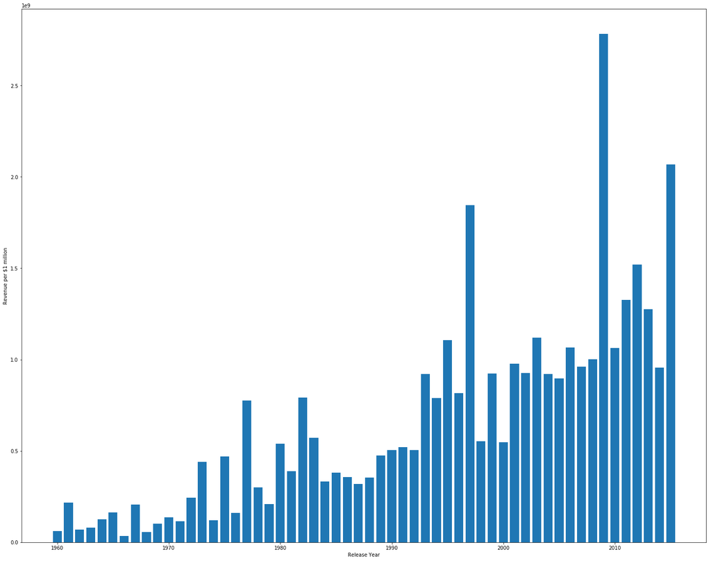

```python
plt.rcParams["figure.figsize"] = (25,20)
#add the x axis
x = tmdb_data.release_year
#add the y axis
y = tmdb_data.revenue
#plot the bar graph
plt.bar(x,y)
#Add labels
plt.xlabel('Release Year')
plt.ylabel('Revenue per $1 million')
```

#### This bar graph does show a trend in higher revenue as the years increase.

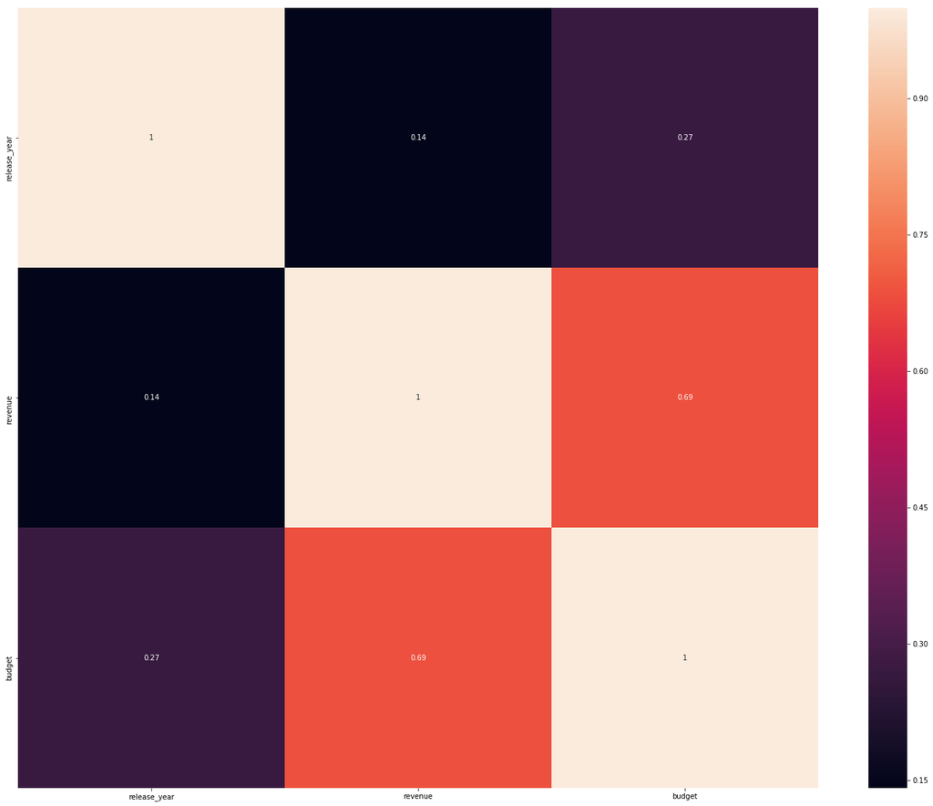

```python
df = pd.DataFrame(tmdb_data,columns=['release_year','revenue','budget'])

corrMatrix = df.corr()
sb.heatmap(corrMatrix, annot=True)
plt.show()
```

#### The correlation matrix above has the variables release year, revenue and budget. The matrix shows that there is a higher correlation between revenue and budget than revenue and years.

# Q2 - Does who the director is matter when it comes to movies and their revenue?

I am going to create a Box plot to easily view the directors and their revenues side by side.

| director | mean | std |
| --- | --- | --- |
| Clint Eastwood | 1.153859e+08 | 1.120811e+08 |
| Martin Scorsese | 1.157014e+08 | 1.208584e+08 |
| Ridley Scott | 1.706872e+08 | 1.719192e+08 |
| Steven Spielberg | 3.340209e+08 | 2.312726e+08 |
| Woody Allen | 4.154744e+07 | 4.168138e+07 |

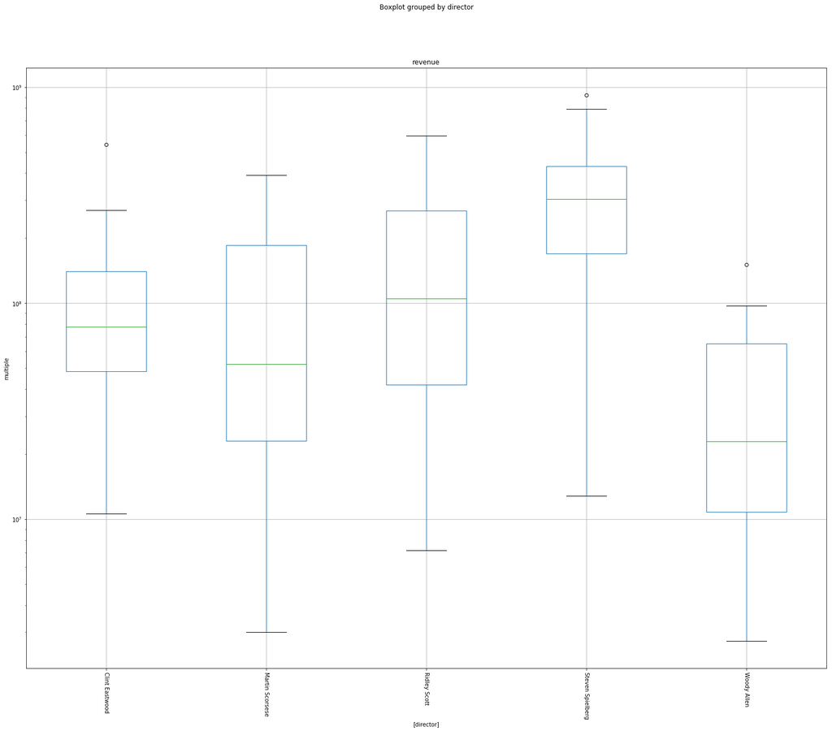

```python
boxplot=tmdb_data.groupby(['director'])[['id']].count().sort_values(by=['id'], ascending=False)[0:5]
boxplot_new = tmdb_data[tmdb_data['director'].isin(boxplot.index.values.tolist())]
#remove any revenue that is 0 or less
boxplot_new1=boxplot_new[boxplot_new['revenue']>0]
boxplot_new1.boxplot(column=['revenue'], by = ['director'], rot=270).set_yscale('log')
#add y label
plt.ylabel("multiple")
pd.DataFrame(boxplot_new1.groupby(['director'])['revenue'].describe().loc[:,['mean','std']])
```

### This box plot shows relationship between a categorical feature (Directors) and a continuous feature (multiple).

## Conclusions

In conclusion we can tell that the first chart for question 1 shows us there is an upward trend. From 1960-2015 there has been an upward trend in revenue. A few years have gone below that trend line but most have been going upward. The matrix however shows a higher correlation between budget and revenue.

For our second question we are asking whether revenue is determined by director. I believe this question may be hard or impossible to answer with this limited data. I can however comment that it seems Stephen Spielberg has a greater chance of having a high revenue than the other 4 directors in the list.

### Limitations

1.The only dataset we used was from TMBD Movies which only provided a sample of the movies throughout the U.S.A. This dataset does not include every director and it only goes through 2015.

2.Values that were null were dropped from their respected variables. This could have unbalanced the data.

3.Revenues and budgets were not confirmed or verified. As such there may have been currency rates that were different and need to be converted.

```python
from subprocess import call
call(['python', '-m', 'nbconvert', 'Investigate_a_Dataset.ipynb'])
```